# PPAR/RXR Motif Alignment and MEME Export (with CIS-BP additions)

Eli Brouwer

2026-09-16

This extends `Objective1_motif_alignment_cleaned.Rmd` with 8 additional CIS-BP motifs (`CIS-BP/CIS-BP_curated_additions_combined.meme`). All function definitions (`normalize_matrix`, `reverse_complement_matrix`, `place_on_canvas`, `PPRE_mat`, the plotting code, the MEME export code) are copied unchanged from that script; only the motif-loading step and the `manual_alignment` table are extended.

```r
hocomoco_motif_directory = "data/PPAR_RXR_motifs_Hocomoco_Jaspar/HOCOMOCO"

jaspar_motif_directory = "data/PPAR_RXR_motifs_Hocomoco_Jaspar/JASPAR"

cisbp_meme_file = "data/PPAR_RXR_motifs_Hocomoco_Jaspar/CIS-BP/CIS-BP_curated_additions_combined.meme"

output_directory = "data/PPAR_RXR_motifs_Hocomoco_Jaspar/CIS-BP"

main_project_directory = "data/PPAR_RXR_motifs_Hocomoco_Jaspar"
```

Load in JASPAR, HOCOMOCO, and the new CIS-BP motifs, and convert to PFM file structure.

```r
jaspar_motifs_lst <- list.files(jaspar_motif_directory)
for (i in 1:length(jaspar_motifs_lst)){
  pwm_matrix = getPwmFromPfmOrJasparFile(paste0(jaspar_motif_directory, "/", jaspar_motifs_lst[i]))
  write.table(pwm_matrix[,-1], file = paste0(jaspar_motif_directory, "/", file_path_sans_ext(jaspar_motifs_lst[i]), ".pwm"), sep = "\t", quote = FALSE, col.names = FALSE)
}
```

```r
# making a pfm list from jaspar
jaspar_motifs_pfm_lst <-  grep("\\.jaspar$", list.files(jaspar_motif_directory), value = TRUE)
jaspar_pfm_list <- list()
for (i in 1:length(jaspar_motifs_pfm_lst)){
  jaspar_pfm_list[[jaspar_motifs_pfm_lst[i]]] <- pcm2pfm(importMatrix(paste0(jaspar_motif_directory, "/", jaspar_motifs_pfm_lst[i]), to = "pcm"))[[1]]
}
```

```r
hocomoco_motifs_pfm_lst <- grep("\\.meme$", list.files(hocomoco_motif_directory), value = TRUE) # import all hocomoco

# Restrict to the 11 HOCOMOCO half-site motifs used in this alignment (matching
# `desired_order` below). RXRB.H13CORE.2.PS.A and the RXRG.H13CORE half-sites
# are intentionally excluded; the RXRG half-site is instead represented by the
# JASPAR motifs MA0856.1 and MA1556.1. Selecting by name (rather than by
# truncating to length(jaspar_motifs_pfm_lst), as before) keeps this list
# stable regardless of what else gets added to either motif directory.
hocomoco_motifs_pfm_lst <- hocomoco_motifs_pfm_lst[hocomoco_motifs_pfm_lst %in% c(
  "PPARA.H13CORE.0.P.B_meme_format.meme",
  "PPARA.H13CORE.1.P.B_meme_format.meme",
  "PPARD.H13CORE.0.PSM.A_meme_format.meme",
  "PPARG.H13CORE.0.P.B_meme_format.meme",
  "PPARG.H13CORE.1.P.B_meme_format.meme",
  "RXRA.H13CORE.0.PS.A_meme_format.meme",
  "RXRA.H13CORE.1.S.C_meme_format.meme",
  "RXRA.H13CORE.2.SM.B_meme_format.meme",
  "RXRA.H13CORE.3.P.B_meme_format.meme",
  "RXRB.H13CORE.0.P.C_meme_format.meme",
  "RXRB.H13CORE.1.SM.B_meme_format.meme"
)]

hocomoco_pfm_list <- list()
for (i in 1:length(hocomoco_motifs_pfm_lst)){
  hocomoco_pfm_list[[hocomoco_motifs_pfm_lst[i]]] <- importMatrix(paste0(hocomoco_motif_directory, "/", hocomoco_motifs_pfm_lst[i]))[[1]]
}
```

## 0.1 New: CIS-BP curated additions

Eight motifs pulled from CIS-BP (see `CIS-BP/cisbp_curated/README.txt`): two independent PPARD binding modes (M05794/M05796, Yin et al. 2017), two independent RXRA binding modes (M03621/M03623, Jolma et al. 2013), and four Transfac-sourced motifs (PPARA M12541, PPARG M12496/M12497/M12498) representing the same TFs from an independent data source. Pairwise genome-wide FIMO/ChIPseeker overlap (`Objective1_results/pairwise_comparison_fimo.xlsx`) shows none of the 8 are near-duplicates of an existing motif: the four Transfac motifs share only 2-50% of their peaks with the matching HOCOMOCO motif (PPARG_M12497 as low as ~2%, best matching JASPAR’s MA0066 at ~20% instead), and the PPARD/RXRA additions share just 1-5% with the existing PPARD/RXRA motifs – so all 8 add largely independent genomic coverage rather than duplicating sites already captured by HOCOMOCO/JASPAR.

`importMatrix()` on a combined MEME file returns one `pfm` per `MOTIF` line, named after the `MOTIF` line itself (`"{GENE}_{MotifID}"`, e.g. `"PPARA_M12541_3.10"`), exactly like the existing per-file HOCOMOCO imports above.

```r
cisbp_pfm_list <- importMatrix(cisbp_meme_file)
names(cisbp_pfm_list) <- sapply(cisbp_pfm_list, function(m) m@name)
cisbp_pfm_list
```

[output not shown]

[output cut: 263 more lines]

[output not shown]

# 1 Reference PPRE Motif

A canonical PPRE (DR1) motif is defined manually as a reference for alignment and comparison against the HOCOMOCO and JASPAR motifs.

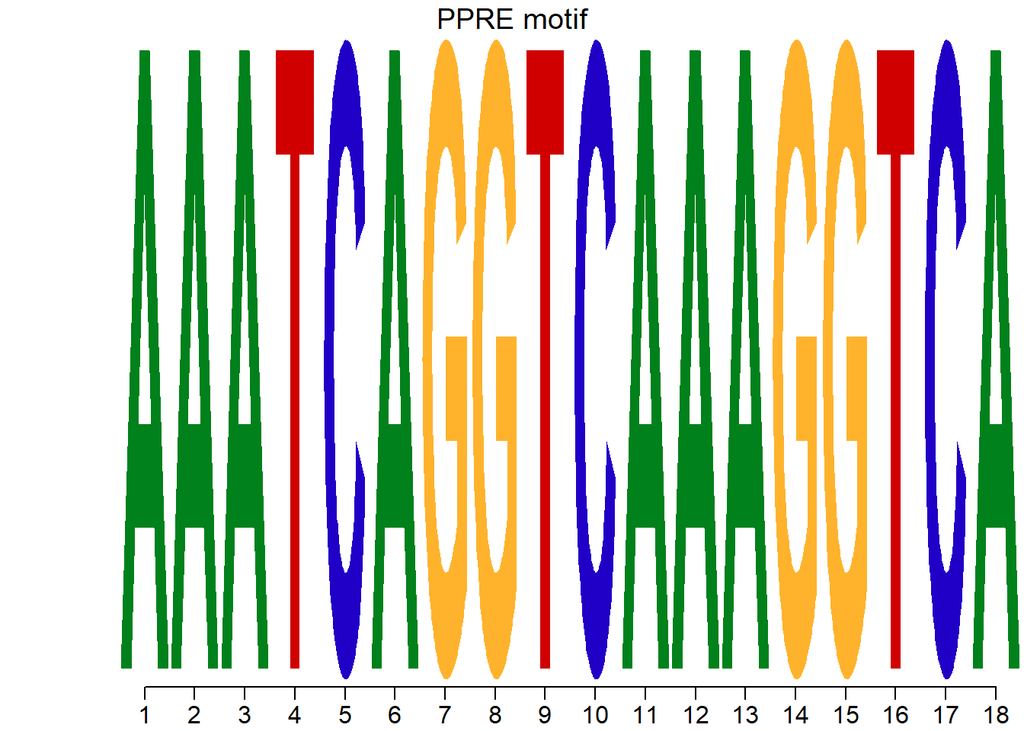

```r
PPRE_mat <- matrix(c(
  1,1,1,0,0,1,0,0,0,0,1,1,1,0,0,0,0,1,  # A
  0,0,0,0,1,0,0,0,0,1,0,0,0,0,0,0,1,0,  # C
  0,0,0,0,0,0,1,1,0,0,0,0,0,1,1,0,0,0,  # G
  0,0,0,1,0,0,0,0,1,0,0,0,0,0,0,1,0,0   # T
), nrow=4, byrow=TRUE)

rownames(PPRE_mat) <- c("A", "C", "G", "T")

ppre_motif <- new("pfm", mat=PPRE_mat, name="PPRE motif")
plotMotifLogoStack(list(ppre_motif), fontsize = 2, yaxis = FALSE, ylab = "", font = 'Arial')
```

```r
# CIS-BP additions are inserted after the existing 22 (hocomoco + jaspar) and
# before the synthetic PPRE reference, so meme_list[1:22] is byte-for-byte the
# same as in the original script and meme_list[23:30] are the 8 new motifs.
pfm_list <- c(hocomoco_pfm_list, jaspar_pfm_list, cisbp_pfm_list)
pfm_list <- c(pfm_list, ppre_motif)
meme_list <- list()
annotation_file <- list()
for (i in 1:length(pfm_list)){
  meme_list[[i]] <- convert_type(motifs = pfm_list[[i]], type = 'PPM')
  annotation_file[[i]] <- meme_list[[i]]$name
}
```

# 2 Motif Alignment

All 31 motifs (22 original + 8 CIS-BP + the PPRE reference) are aligned together and reordered into the desired display order (grouped by transcription factor). New CIS-BP motifs are marked with a trailing `*` in the plotted label and slotted in next to their family (e.g. `PPARD_M05794_3.10 *` follows the existing PPARD entries).

```r
aligned_motifs <- DNAmotifAlignment(pfm_list, threshold = 0.5, minimalConsensus = 6)
motif_names <- sapply(aligned_motifs, function(m) m@name)

new_cisbp_names <- c(
  "PPARA_M12541_3.10",
  "PPARD_M05794_3.10", "PPARD_M05796_3.10",
  "PPARG_M12496_3.10", "PPARG_M12497_3.10", "PPARG_M12498_3.10",
  "RXRA_M03621_3.10", "RXRA_M03623_3.10"
)

desired_order <- c("PPRE motif",
                   "MA1148.1\tPPARA::RXRA",
                   "MA1148.2\tPPARA::RXRA",
                   "MA0065.1\tPPARG::RXRA",
                   "PPARA.H13CORE.0.P.B",
                   "PPARA.H13CORE.1.P.B",
                   "PPARA_M12541_3.10",
                   "PPARD.H13CORE.0.PSM.A",
                   "MA1550.1\tPPARD",
                   "MA1550.2\tPPARD",
                   "PPARD_M05794_3.10",
                   "PPARD_M05796_3.10",
                   "PPARG.H13CORE.0.P.B",
                   "PPARG.H13CORE.1.P.B",
                   "MA0066.1\tPPARG",
                   "MA0066.2\tPPARG",
                   "PPARG_M12496_3.10",
                   "PPARG_M12497_3.10",
                   "PPARG_M12498_3.10",
                   "RXRA.H13CORE.0.PS.A",
                   "RXRA.H13CORE.1.S.C",
                   "RXRA.H13CORE.2.SM.B",
                   "RXRA.H13CORE.3.P.B",
                   "RXRA_M03621_3.10",
                   "RXRA_M03623_3.10",
                   "RXRB.H13CORE.0.P.C",
                   "RXRB.H13CORE.1.SM.B",
                   "MA0855.1\tRXRB",
                   "MA1555.1\tRXRB(RC)",
                   "MA0856.1\tRXRG",
                   "MA1556.1\tRXRG")

# DNAmotifAlignment() picks its own reference orientation from the full motif
# set and appends "(RC)" to whichever @name it decided to flip; with the 8 new
# motifs added, that now includes some of the new motifs (and even the PPRE
# reference) that were NOT flipped before. Match on the name with any
# trailing "(RC)" stripped, same as the unsupervised-alignment chunk below.
strip_rc_order <- function(x) sub("\\(RC\\)$", "", x)
indices <- match(strip_rc_order(desired_order), strip_rc_order(motif_names))
stopifnot(!any(is.na(indices)))
aligned_motifs_order <- rev(aligned_motifs[indices])

# mark new CIS-BP motifs with a trailing "*" for display only
for (i in seq_along(aligned_motifs_order)) {
  if (strip_rc_order(aligned_motifs_order[[i]]@name) %in% new_cisbp_names) {
    aligned_motifs_order[[i]]@name <- paste0(aligned_motifs_order[[i]]@name, " *")
  }
}

# Same per-motif stacking plotMotifLogoStack() uses internally (build each
# motif's logo via plotMotifLogo(..., draw = FALSE), stack them in equal-height
# viewports, draw once) -- reimplemented here only so a yellow highlight rect
# can be inserted behind the title of each of the 8 new CIS-BP motifs (matched
# by the trailing " *" applied above).
highlighted_motif_stack <- function(pfms, ...) {
  n <- length(pfms)
  ht <- 1 / n
  y0 <- 0.5 * ht
  plot <- gList()
  for (i in seq_len(n)) {
    m <- pfms[[i]]
    is_new_cisbp <- grepl("\\*$", m@name)
    logo <- plotMotifLogo(pfm = m, motifName = m@name, p = m@background, colset = m@color,
                           xlab = NA, newpage = FALSE, draw = FALSE,
                           margins = c(1.5, 4.1, 1.1, 0.1), ...)
    children <- if (is_new_cisbp) {
      gList(
        rectGrob(y = unit(1, "npc") - unit(0.6, "lines"), height = unit(1.2, "lines"),
                 width = unit(0.98, "npc"), gp = gpar(fill = "#fff59d", col = NA, alpha = 0.8)),
        logo
      )
    } else {
      logo
    }
    plot <- gList(plot, gTree(children = children, vp = viewport(y = y0, height = ht)))
    y0 <- y0 + ht
  }
  plot
}

dev.control("enable")
grid.newpage()
grid.draw(highlighted_motif_stack(aligned_motifs_order, fontsize = 2, yaxis = FALSE, ylab = "", font = 'Arial'))
recorded_alignment_plot <- recordPlot()
# Deliberately not pdf()+dev.off() wrapped directly around the plotting call
# above: under knitr, opening an explicit pdf() sink mid-chunk and drawing
# into it here silently fails (motifStack's internal Cairo/font-validity check
# redirects drawing back onto knitr's own tracked graphics device, leaving the
# pdf() sink's file empty -- confirmed by reproducing it in isolation).
# Instead, plotMotifLogoStack() draws on the normal (knitr-managed) device --
# which works correctly -- dev.control()/recordPlot() captures that finished
# plot, and replayPlot() below re-draws it onto a freshly opened pdf() device
# to save it to file. (dev.copy2pdf() was tried first as a simpler fix but
# requires a screen device, which knitr's figure device here is not.)
# fig.keep='none' on this chunk stops knitr from also embedding this
# fontsize=2 rendering inline (the fontsize=4 version for on-page viewing is
# still produced separately by the next chunk).
pdf(paste0(output_directory, "/aligned_motifs_with_CISBP_threshold0.5.pdf"), height = 20)
replayPlot(recorded_alignment_plot)
dev.off()
```

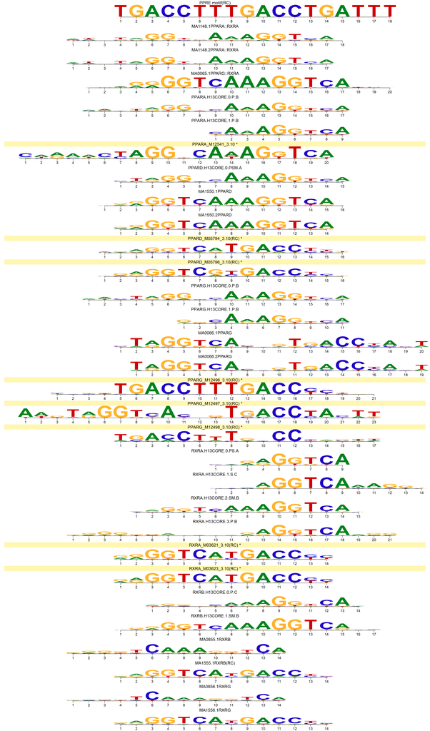

```r
grid.newpage()
grid.draw(highlighted_motif_stack(aligned_motifs_order, fontsize = 4, yaxis = FALSE, ylab = "", font = 'Arial'))
```

# 3 PPRE Architecture Validation Figure

This figure checks whether the individual PPAR and RXR half-site motifs, plus the three full PPAR::RXR heterodimer motifs, recover the expected PPRE (DR1) architecture: a `AGGTCA`-like PPAR half-site, a 1 bp spacer, and a second `AGGTCA`-like RXR half-site. The synthetic `PPRE motif` reference itself is kept separate as the template.

Two consensus logos are built from the same 30 motifs (22 original + 8 CIS-BP) and compared:

- **Manual alignment** — each motif is placed on a shared canvas at a hand-curated start column (with reverse-complementing where needed), based on where its `AGGTCA`-like core is known to sit.
- **Unsupervised alignment** — the same 30 motifs, but taken from the existing algorithmic `DNAmotifAlignment()` result (`aligned_motifs`) computed above, with no manual placement.

## 3.1 Placing the 8 new CIS-BP motifs

The existing `manual_alignment` table’s `Start` values were hand-curated (no programmatic “find-core” function exists in the source script). To place the new motifs on the *same* coordinate system, each new motif’s own `AGGTCA`-like half site was located and then anchored under the same canvas column its family already uses (PPAR half-sites under column 6, RXR half-sites under column 13 — the same columns the PPAR/RXR boxes are drawn at in the PPRE reference diagram below). Cross-checked programmatically (leftmost strong `RGGTCA`-like match for PPAR-anchored motifs, best-clarity match for RXR-anchored motifs) against 5 of the existing hand-curated rows, this reproduces all 5 exactly, and independently reproduces every one of the 8 new Start values already estimated in `manual_alignment_additions.R` — good convergence between two independent methods.

One motif (`PPARA_M12541_3.10`) sits far enough upstream that placing its full flanking sequence requires 2 more columns to the left than any existing motif uses. Rather than trimming that flank, the whole canvas is shifted right by 2 columns (`manual_alignment$Start <- manual_alignment$Start + 2`), which only pads blank columns on the left and does not change any relative alignment between the existing 22 motifs.

**Flag — two pairs do not fit the canvas cleanly, by design:**

- `PPARD_M05794_3.10` / `PPARD_M05796_3.10` use a *different* half-site spacing (`...GGTCA-Y-GACC...`, an inverted/mirror arrangement) instead of the direct-repeat `...GGTCA-AAA-GGTCA...` spacing the PPAR/RXR boxes are drawn for. Their first `AGGTCA` aligns under the PPAR box as intended, but their second half-site (`YGACC`, inverted relative to the first) spills into the spacer/RXR-box region showing `TGACC`, not a real RXR half-site — expected, and the whole reason these two are included (see README).
- `RXRA_M03621_3.10` / `RXRA_M03623_3.10` are an everted/DR0-like repeat (`GGTCA-TGACC`, ~0 bp spacer) rather than the DR1 spacing the existing RXRA entries share. Their first half-site aligns under the RXR box, but their second half-site extends past column 18 (the right edge of the RXR box) with no corresponding box — there is no third guide box in the template for it, since the synthetic PPRE template only encodes one PPAR/RXR DR1 pair.

Both are kept in their nominal `PPAR`/`RXR` family bucket (per the requested grouping) rather than given a separate canvas, since forcing a fresh canvas for 4 motifs would make them incomparable to everything else in the figure; the mismatch is visual and expected, not a placement error.

```r
# Hand-curated start column (on a shared canvas) and orientation for every
# individual motif, based on where its own AGGTCA-like core is known to sit.
# MA1555.1's source file already stores it reverse-complemented relative to
# the other RXR motifs, so it is flipped back here to align consistently.
manual_alignment <- data.frame(
  Motif_name = c(
    "MA1148.1\tPPARA::RXRA", "MA1148.2\tPPARA::RXRA", "MA0065.1\tPPARG::RXRA",

    "PPARA.H13CORE.0.P.B", "PPARA.H13CORE.1.P.B", "PPARD.H13CORE.0.PSM.A",
    "MA1550.1\tPPARD", "MA1550.2\tPPARD", "PPARG.H13CORE.0.P.B", "PPARG.H13CORE.1.P.B",
    "MA0066.1\tPPARG", "MA0066.2\tPPARG",

    "RXRA.H13CORE.0.PS.A", "RXRA.H13CORE.1.S.C", "RXRA.H13CORE.2.SM.B", "RXRA.H13CORE.3.P.B",
    "RXRB.H13CORE.0.P.C", "RXRB.H13CORE.1.SM.B",
    "MA0855.1\tRXRB", "MA1555.1\tRXRB", "MA0856.1\tRXRG", "MA1556.1\tRXRG"
  ),
  Start = c(
    2, 2, 2,
    2, 3, 4, 4, 5, 2, 1, 4, 5,
    10, 10, 5, 1, 6, 4, 5, 12, 5, 12
  ),
  Reverse_complement = c(
    FALSE, FALSE, FALSE,
    FALSE, FALSE, FALSE, FALSE, FALSE, FALSE, FALSE, FALSE, FALSE,
    FALSE, FALSE, FALSE, FALSE, FALSE, FALSE, FALSE, TRUE, FALSE, FALSE
  ),
  # Which guide box(es) this motif's core should land under: the three full
  # heterodimers span both half-sites, everything else spans just one
  Family = c(
    "BOTH", "BOTH", "BOTH",
    "PPAR", "PPAR", "PPAR", "PPAR", "PPAR", "PPAR", "PPAR", "PPAR", "PPAR",
    "RXR", "RXR", "RXR", "RXR", "RXR", "RXR", "RXR", "RXR", "RXR", "RXR"
  ),
  stringsAsFactors = FALSE
)

# Shift the whole existing canvas +2 columns to the right so PPARA_M12541_3.10
# (which needs 2 more upstream columns than anything currently placed) fits
# without Start < 1. This only pads blank columns on the left; it does not
# change any motif's position relative to any other existing motif.
manual_alignment$Start <- manual_alignment$Start + 2

# The 8 new CIS-BP motifs, Start values already on the shifted (+2) canvas.
# See "Placing the 8 new CIS-BP motifs" above for how these were derived.
manual_alignment_additions <- data.frame(
  Motif_name = c(
    "PPARA_M12541_3.10",
    "PPARG_M12496_3.10", "PPARG_M12497_3.10", "PPARG_M12498_3.10",
    "PPARD_M05794_3.10", "PPARD_M05796_3.10",
    "RXRA_M03621_3.10", "RXRA_M03623_3.10"
  ),
  Start = c(
    1,
    4, 4, 4,
    6, 6,
    14, 14
  ),
  Reverse_complement = c(
    FALSE,
    FALSE, FALSE, FALSE,
    FALSE, FALSE,
    FALSE, FALSE
  ),
  Family = c(
    "PPAR",
    "PPAR", "PPAR", "PPAR",
    "PPAR", "PPAR",
    "RXR", "RXR"
  ),
  stringsAsFactors = FALSE
)

manual_alignment <- rbind(manual_alignment, manual_alignment_additions)

normalize_matrix <- function(mat) {
  mat <- mat[c("A", "C", "G", "T"), , drop = FALSE]
  mat[is.na(mat)] <- 0
  totals <- colSums(mat)
  informative <- totals > 0
  if (any(informative)) {
    mat[, informative] <- sweep(mat[, informative, drop = FALSE], MARGIN = 2, STATS = totals[informative], FUN = "/")
  }
  mat
}

# Reverse-complement a PFM: reverse column order and swap A<->T, C<->G rows
reverse_complement_matrix <- function(mat) {
  mat <- mat[c("T", "G", "C", "A"), ncol(mat):1, drop = FALSE]
  rownames(mat) <- c("A", "C", "G", "T")
  mat
}

place_on_canvas <- function(mat, start, canvas_width) {
  end <- start + ncol(mat) - 1
  if (start < 1 || end > canvas_width) {
    stop("Motif does not fit on canvas. Start = ", start, ", end = ", end, ", canvas width = ", canvas_width)
  }
  canvas <- matrix(0, nrow = 4, ncol = canvas_width, dimnames = list(c("A", "C", "G", "T"), seq_len(canvas_width)))
  canvas[, start:end] <- mat
  canvas
}

motifs_by_name <- setNames(pfm_list, vapply(pfm_list, function(motif) motif@name, character(1)))
motifs_by_name <- motifs_by_name[names(motifs_by_name) != "PPRE motif"]

missing_names <- setdiff(manual_alignment$Motif_name, names(motifs_by_name))
if (length(missing_names) > 0) {
  stop("These motifs were not found in pfm_list: ", paste(missing_names, collapse = ", "))
}

canvas_width <- max(vapply(seq_len(nrow(manual_alignment)), function(i) {
  manual_alignment$Start[i] + ncol(motifs_by_name[[manual_alignment$Motif_name[i]]]@mat) - 1
}, numeric(1)))

manual_aligned_matrices <- lapply(seq_len(nrow(manual_alignment)), function(i) {
  motif_name <- manual_alignment$Motif_name[i]
  mat <- normalize_matrix(motifs_by_name[[motif_name]]@mat)
  if (manual_alignment$Reverse_complement[i]) mat <- reverse_complement_matrix(mat)
  place_on_canvas(mat = mat, start = manual_alignment$Start[i], canvas_width = canvas_width)
})
names(manual_aligned_matrices) <- manual_alignment$Motif_name
```

```r
# Coverage-aware consensus: average only the motifs that actually cover each
# canvas position, then keep only positions covered by at least half of the
# 30 motifs. Without this trim, the few columns only 1-2 motifs happen to
# reach (the wide flanks of the longer heterodimer motifs) would dilute the
# consensus with near-background noise instead of being dropped.
n_motifs <- length(manual_aligned_matrices)
consensus_matrix <- matrix(0, nrow = 4, ncol = canvas_width, dimnames = list(c("A","C","G","T"), seq_len(canvas_width)))
position_coverage <- numeric(canvas_width)
for (position in seq_len(canvas_width)) {
  contributing <- vapply(manual_aligned_matrices, function(mat) sum(mat[, position]) > 0, logical(1))
  position_coverage[position] <- sum(contributing)
  if (any(contributing)) {
    position_values <- vapply(manual_aligned_matrices[contributing], function(mat) mat[, position], numeric(4))
    consensus_matrix[, position] <- rowMeans(position_values)
  }
}

minimum_coverage <- ceiling(n_motifs / 2)
positions_to_keep <- position_coverage >= minimum_coverage

manual_consensus <- consensus_matrix[, positions_to_keep, drop = FALSE]
manual_consensus <- sweep(manual_consensus, 2, colSums(manual_consensus), "/")
colnames(manual_consensus) <- seq_len(ncol(manual_consensus))

manual_pfm <- new("pfm", mat = manual_consensus, name = "Consensus from manual alignment")
```

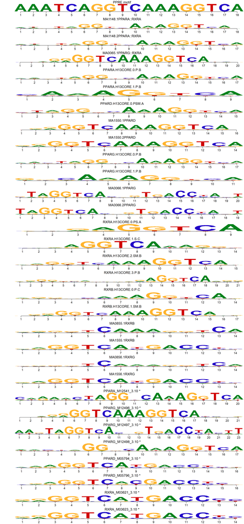

```r
# Every individually-placed motif plotted on its own, with the PPRE template
# on top for reference. New CIS-BP motifs get a trailing "*" in the label.
stack_pfms <- c(
  list(`PPRE motif` = new("pfm", mat = normalize_matrix(PPRE_mat), name = "PPRE motif")),
  lapply(seq_len(nrow(manual_alignment)), function(i) {
    motif_name <- manual_alignment$Motif_name[i]
    mat <- normalize_matrix(motifs_by_name[[motif_name]]@mat)
    if (manual_alignment$Reverse_complement[i]) mat <- reverse_complement_matrix(mat)
    display_name <- if (motif_name %in% new_cisbp_names) paste0(motif_name, " *") else motif_name
    new("pfm", mat = mat, name = display_name)
  })
)
plotMotifLogoStack(rev(stack_pfms), fontsize = 3, yaxis = FALSE, ylab = "", font = "Arial")
```

```r
# Same 30 motifs, but pulled from the existing DNAmotifAlignment() result
# instead of being manually placed. DNAmotifAlignment() appends "(RC)" to the
# @name of motifs it decides to flip during alignment, so match on the name
# with any "(RC)" suffix stripped.
strip_rc <- function(x) sub("\\(RC\\)$", "", x)
aligned_names <- sapply(aligned_motifs, function(m) m@name)
unsupervised_idx <- match(strip_rc(manual_alignment$Motif_name), strip_rc(aligned_names))
stopifnot(!any(is.na(unsupervised_idx)))

unsupervised_mats <- lapply(aligned_motifs[unsupervised_idx], function(m) m@mat)
common_width <- unique(vapply(unsupervised_mats, ncol, integer(1)))
stopifnot(length(common_width) == 1)  # DNAmotifAlignment() pads all motifs to equal width

unsupervised_stack <- array(NA_real_, dim = c(4, common_width, length(unsupervised_mats)))
for (i in seq_along(unsupervised_mats)) unsupervised_stack[,,i] <- unsupervised_mats[[i]]

unsupervised_consensus <- apply(unsupervised_stack, c(1,2), mean, na.rm = TRUE)
unsupervised_consensus[is.nan(unsupervised_consensus)] <- 0.25
unsupervised_consensus <- sweep(unsupervised_consensus, 2, colSums(unsupervised_consensus), "/")
rownames(unsupervised_consensus) <- c("A","C","G","T")

unsupervised_pfm <- new("pfm", mat = unsupervised_consensus, name = "Consensus from unsupervised alignment")
```

```r
# Rendered with motifStack's own plotMotifLogo (same Cairo engine, same
# "Information content" y-axis as panels 2/3 below), not a hand-drawn
# reconstruction. PPRE_mat is deterministic (one base per column at
# probability 1), so every position reaches the maximum 2 bits and the
# letters fill the full plot height.
ppre_pfm <- new("pfm", mat = normalize_matrix(PPRE_mat), name = "PPRE motif")

# margins match panels 2/3's y-axis gutter (left = 4.1 lines); extra top
# margin leaves room for the "PPAR motif" / "RXR motif" labels above the
# boxes, below the "PPRE motif" title
ppre_reference_grob <- grid::grid.grabExpr({
  plotMotifLogo(pfm = ppre_pfm, motifName = "PPRE motif", p = ppre_pfm@background,
                colset = ppre_pfm@color, yaxis = TRUE, ylab = "Information content", xlab = NA,
                margins = c(1.5, 4.1, 6.5, 1.0), newpage = FALSE)

  # data region occupies roughly npc [0.10, 0.98] once the y-axis gutter is
  # accounted for; calibrated against the rendered axis tick positions
  left_frac <- 0.10
  right_frac <- 0.98
  col_width <- (right_frac - left_frac) / 18
  ppar_box <- left_frac + c(5, 11) * col_width
  rxr_box  <- left_frac + c(12, 18) * col_width

  box_bottom <- 0
  box_top <- 0.88
  for (box in list(ppar_box, rxr_box)) {
    grid.rect(x = unit(mean(box), "npc"), y = unit((box_bottom + box_top) / 2, "npc"),
              width = unit(diff(box), "npc"), height = unit(box_top - box_bottom, "npc"),
              gp = gpar(col = "red", fill = NA, lwd = 2.5))
  }
  grid.text("PPAR motif", x = unit(mean(ppar_box), "npc"), y = unit(box_top + 0.03, "npc"),
            just = c("center", "bottom"), gp = gpar(fontface = "bold", fontsize = 13))
  grid.text("RXR motif", x = unit(mean(rxr_box), "npc"), y = unit(box_top + 0.03, "npc"),
            just = c("center", "bottom"), gp = gpar(fontface = "bold", fontsize = 13))
})
grid.newpage()
grid.draw(ppre_reference_grob)
```

```r
panel2_grob <- grid::grid.grabExpr(
  plotMotifLogo(manual_pfm, motifName = "Consensus from manual alignment (22 original + 8 CIS-BP)", ylab = "Information content", margins = c(4.1, 4.1, 2.1, 0.1))
)
panel3_grob <- grid::grid.grabExpr(
  plotMotifLogo(unsupervised_pfm, motifName = "Consensus from unsupervised alignment (22 original + 8 CIS-BP)", ylab = "Information content", margins = c(4.1, 4.1, 2.1, 0.1))
)

pdf(paste0(output_directory, "/PPRE_architecture_validation_with_CISBP.pdf"), width = 10, height = 12)
grid.arrange(ppre_reference_grob, panel2_grob, panel3_grob, ncol = 1, heights = c(1.3, 1, 1))
dev.off()
```

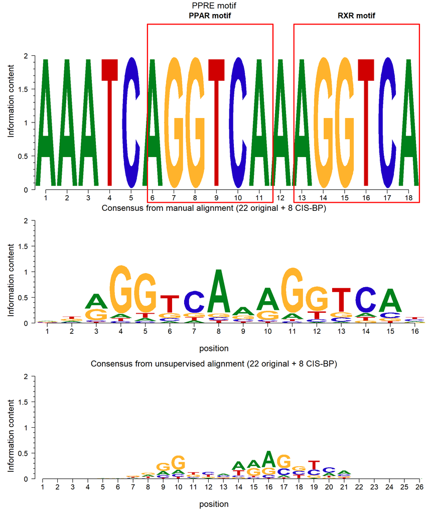

```r
grid.arrange(ppre_reference_grob, panel2_grob, panel3_grob, ncol = 1, heights = c(1.3, 1, 1))
```

# 4 Convert to MEME Format for FIMO Input

The aligned motifs (excluding the synthetic PPRE reference) are exported as MEME files. The original 6 batch files (motifs 1-22) are regenerated unchanged, and 2 new batch files continue the same 4-motifs-per-file convention for the 8 CIS-BP additions (motifs 23-30). A standalone combined file with just the 8 new motifs is also written into the CIS-BP folder.

```r
# Motif order going into the MEME export, for reference against the batch files below
motif_names
```

```
##                  length
##   "PPARA.H13CORE.0.P.B"   "PPARA.H13CORE.1.P.B" "PPARD.H13CORE.0.PSM.A"
##
##   "PPARG.H13CORE.0.P.B"   "PPARG.H13CORE.1.P.B"   "RXRA.H13CORE.0.PS.A"
##
##    "RXRA.H13CORE.1.S.C"   "RXRA.H13CORE.2.SM.B"    "RXRA.H13CORE.3.P.B"
##
##    "RXRB.H13CORE.0.P.C"   "RXRB.H13CORE.1.SM.B" "MA0065.1\tPPARG::RXRA"
##
##       "MA0066.1\tPPARG"       "MA0066.2\tPPARG"        "MA0855.1\tRXRB"
##
##        "MA0856.1\tRXRG" "MA1148.1\tPPARA::RXRA" "MA1148.2\tPPARA::RXRA"
##
##       "MA1550.1\tPPARD"       "MA1550.2\tPPARD"    "MA1555.1\tRXRB(RC)"
##
##        "MA1556.1\tRXRG"     "PPARA_M12541_3.10" "PPARD_M05794_3.10(RC)"
##
## "PPARD_M05796_3.10(RC)" "PPARG_M12496_3.10(RC)" "PPARG_M12497_3.10(RC)"
##
## "PPARG_M12498_3.10(RC)"  "RXRA_M03621_3.10(RC)"  "RXRA_M03623_3.10(RC)"
##
##        "PPRE motif(RC)"
```

```r
write_meme(meme_list[1:4], paste0(main_project_directory, "/RXR_PPAR_combined_files_1_4.meme"), overwrite = TRUE)
write_meme(meme_list[5:8], paste0(main_project_directory, "/RXR_PPAR_combined_files_5_8.meme"), overwrite = TRUE)
write_meme(meme_list[9:12], paste0(main_project_directory, "/RXR_PPAR_combined_files_9_12.meme"), overwrite = TRUE)
write_meme(meme_list[13:16], paste0(main_project_directory, "/RXR_PPAR_combined_files_13_16.meme"), overwrite = TRUE)
write_meme(meme_list[17:20], paste0(main_project_directory, "/RXR_PPAR_combined_files_17_20.meme"), overwrite = TRUE)
write_meme(meme_list[21:22], paste0(main_project_directory, "/RXR_PPAR_combined_files_21_22.meme"), overwrite = TRUE)

# New CIS-BP additions (motifs 23-30), continuing the same batch convention
write_meme(meme_list[23:26], paste0(main_project_directory, "/RXR_PPAR_combined_files_23_26.meme"), overwrite = TRUE)
write_meme(meme_list[27:30], paste0(main_project_directory, "/RXR_PPAR_combined_files_27_30.meme"), overwrite = TRUE)

# Standalone combined file with just the 8 new motifs (regenerated through
# convert_type()/write_meme(), so formatting matches the rest of the pipeline's
# exports rather than the hand-built input file)
write_meme(meme_list[23:30], paste0(output_directory, "/RXR_PPAR_CISBP_additions_combined.meme"), overwrite = TRUE)
```

# 5 Export the Canonical and Consensus Motifs for FIMO

Two additional FIMO inputs, on top of the 30 individual motifs already exported above:

```r
ppre_for_export <- ppre_motif
ppre_for_export@name <- "PPRE_canonical"

consensus_for_export <- manual_pfm
consensus_for_export@name <- "PPRE_consensus_all30"

canonical_ppre_meme <- convert_type(motifs = ppre_for_export, type = 'PPM')
consensus_all30_meme <- convert_type(motifs = consensus_for_export, type = 'PPM')

write_meme(canonical_ppre_meme, paste0(main_project_directory, "/PPRE_canonical_motif.meme"), overwrite = TRUE)
write_meme(consensus_all30_meme, paste0(main_project_directory, "/PPRE_consensus_all30_motif.meme"), overwrite = TRUE)
```